# B.F.3 Übung zu Diagnostik/Testtheorie

Klassische Testtheorie

Bißantz, S., Kuch, S. & Gürtler, R.-M.

Rheinland-Pfälzische Technische Universität Kaiserslautern-Landau

Folien als PDF

## Semesterübersicht

| Nr. | Datum | Thema |
| --- | --- | --- |
| 1 | ab 20.10. | Einführung & Rechenkompetenzen |
| 2 | ab 27.10. | Rechenkompetenzen |
| 3 | ab 03.11. | Gütekriterien |
| 4 | ab 10.11. | Schritte der Testkonstruktion & Erstellung eines Testentwurfs |
|  |  | **Lektürewoche** |
| 5 | ab 24.11. | Klassische Testtheorie |
| 6 | ab 01.12. | *Diagnostische Rechenkompetenzen I* |
| 7 | ab 08.12. | *Item-Response-Theorie* |
| 8 | ab 15.12. | Exploratorische Faktorenanalyse I |
|  |  | **Weihnachtsferien** |
| 9 | ab 05.01. | *Exploratorische Faktorenanalyse II* |
| 10 | ab 12.01. | Itemanalyse I |
| 11 | ab 19.01. | Itemanalyse II, Itemselektion und Testrevision |
| 12 | ab 26.01. | *Diagnostische Rechenkompetenzen II* |
| 13 | ab 02.02. | Gütekriterien II |

# Überblick

## Themen der heutigen Sitzung

Klassische Testtheorie (KTT)

1. Grundannahmen
2. Reliabilität
3. Messmodelle

# Grundannahmen

## Wozu eine Testtheorie?

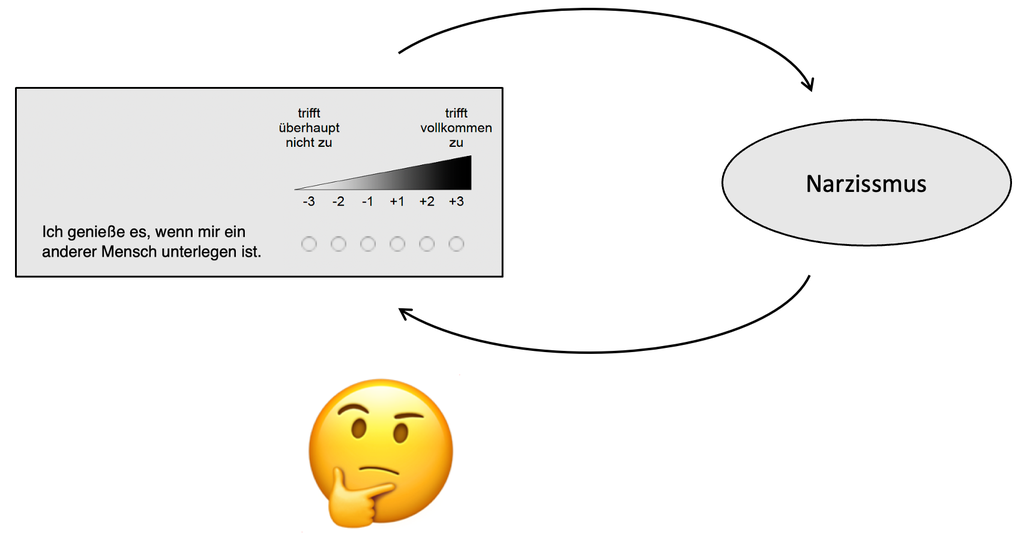

- Wie hängen Messung und latentes Konstrukt zusammen?
- Welche Rolle spielen Messfehler?
- Wie kann ich einen Test-Score berechnen und interpretieren?
- Wie muss mein Test konstruiert sein?

## Der Ansatz der Klassischen Testtheorie

**Modell der Klassischen Testtheorie**

$$X = T + E \tag{1}$$

- $T$: Wahrer Wert
- $X$: Beobachtungswert, Testwert
- $E$: Fehlerkomponente, Messfehler
- Häufig ist $X$ der Summenscore von $k$ Items $i=1,\dots,k$, sodass:

$$X = \sum_{i=1}^k x_i \tag{2}$$

## Grundannahmen

*Population*

- Personen sind (daraus) eine Zufallsstichprobe
- Für jede Person liegt theoretisch eine infinite Anzahl von Messergebnissen vor

*Itemuniversum*

- Alle Items stammen aus einem infiniten Itemuniversum
- Jedes Item (darin) ist zur Messung der latenten Variable geeignet

Verwandte Konzepte: interindividuelle und intraindividuelle Merkmalsverteilung

## Werteverteilungen & Gedankenexperiment

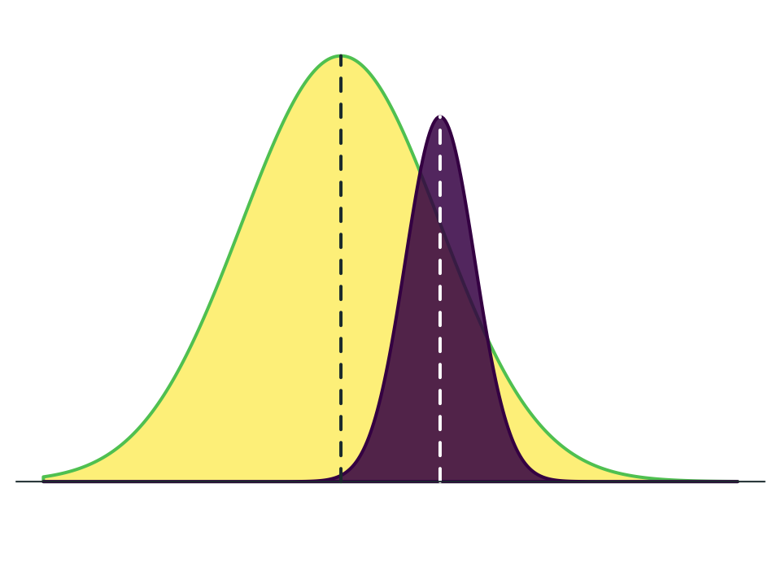

Abbildung 1: Intra- (dunkel) und interindividuelle (hell) Werteverteilungen

**Gedankenexperiment**

Hätten wir die Möglichkeit, eine Person unzählige Male unter den gleichen Bedingungen zu messen, dann erhielten wir eine (Normal-)Verteilung ihrer Messwerte. Der Mittelwert der intraindividuellen Messwerte entspräche dem wahren Wert der Person.

$$E \sim \mathrm{N}(0, \sigma^2) \tag{3}$$

## Fluktuationsphänomen

**Unsystematische Fehlerkomponente**

$$\mathbb{E}(E) = 0 \tag{4}$$

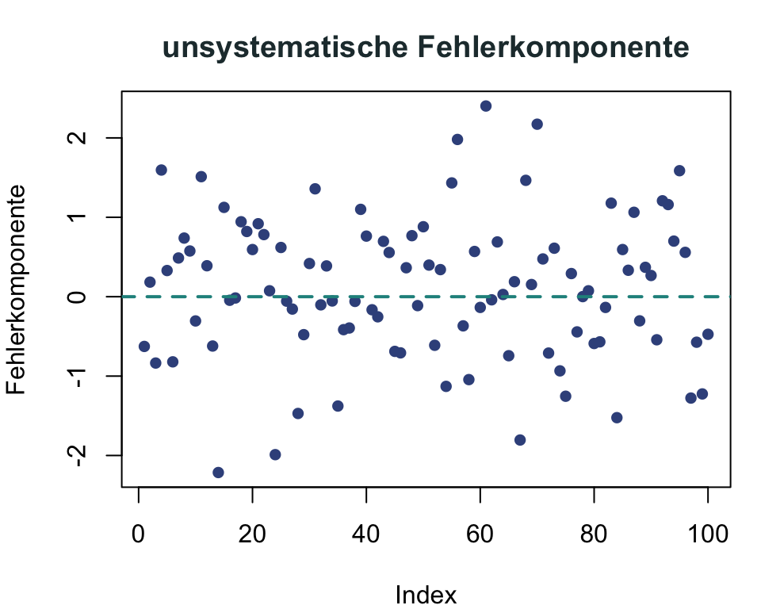

Abbildung 2: Zufällige Fehlerwerte streuen ohne Muster um 0

## Fluktuationsphänomen

- Annahme: Wenn die Störeinflüsse zufällig sind, gleichen sie sich im Mittel aus
- Implikation: Mittel der Beobachtungswerte entspricht dem wahren Wert

**Vermutung als formale Implikation**

$$\mathbb{E}(E) = 0 \tag{4}$$

$$\mathbb{E}(X) = T \tag{5}$$

## Das Problem wiederholter Messung

**Das Problem wiederholter Messung**

Wir messen (oft) nur ein einziges Mal und ziehen damit (zufällig) aus der Verteilung der intraindividuellen Messwerte. Der Messwert ist ein Schätzer für den wahren Wert der Person, der wegen des Messfehlers unter oder über dem Messwert liegen kann.

**Gedankenexperiment**

Hätten wir die Möglichkeit, eine Person unzählige Male unter den gleichen Bedingungen zu messen, dann erhielten wir eine (Normal-)Verteilung ihrer Messwerte, wobei im Mittel über alle intraindividuellen Messwerte die Beobachtungswerte dem wahren Wert der Person entsprechen.

# Reliabilität

## Reliabilität nach der KTT

- Aussage über die Qualität eines Messinstruments, Tests, einer Skala
- „Qualität“ in der KTT bedeutet…
  - Abwesenheit von Messfehlern
  - Konsistente Messwerte bei wiederholter Messung einer LV
  - Akkuratheit bei der Messung von wahren Werten (Coaley, 2014)

**Reliabilität ($\text{Rel}$)**

$$\begin{split}
\text{Rel}(X) & = \frac{\text{Var}(T)}{\text{Var}(X)} = \frac{\text{Var}(T)}{\text{Var}(T) + \text{Var}(E)} \\
\text{Rel}(X) & \in [0,1]
\end{split} \tag{6}$$

## Methoden der Reliabilitätsschätzung

**Das Berechnungsproblem**

$\text{Rel}(X)$ ist nicht (direkt) berechenbar, da wir z. B. $\text{Var}(T)$ nicht kennen.

**Mögliche Lösungsansätze**

*a. Klassische Methoden:*

- Verschiedene Items, die dasselbe Merkmal messen
- Wiederholte Messung anhand desselben oder mehrerer Tests
- Methoden: Retest-, Paralleltest- und Testhalbierungsreliabilität, interne Konsistenz

*b. Modellbasierte Methoden*

- Messmodelle
- Beruhen auf Stichprobenkennwerten (Kovarianzen und Korrelationen)

# Messmodelle

## Wieso interessieren wir uns für Messmodelle?

[figure not shown]

Es kann nützlich sein, zwei gleichwertige Versionen desselben Tests zu haben („Parallelformen“).

- Messwiederholung
- Gruppentestung
- …

$\rightarrow$ Wie lässt sich überprüfen, ob die Testwerte vergleichbar sind?

## Messmodellgleichung

**Wahre Werte und Messmodellgleichung**

Der wahre Wert einer Person auf Item $i$ wird definiert als:

$$\tau_i = \alpha_i + \lambda_i \cdot \eta \tag{7}$$

Die beobachtete Antwort $x_i$ setzt sich zusammen aus:

$$x_i = \alpha_i + \lambda_i \cdot \eta + \varepsilon_i \tag{8}$$

- $\alpha_i$: Interzept (Schwierigkeitsparameter)
- $\lambda_i$: Ladung (Trennschärfeparameter)
- $\eta$: Latente Variable
- $\varepsilon_i$: Messfehler

(vgl. Moosbrugger & Kelava, 2020, S. 283)

## Übersicht eindimensionaler Messmodelle

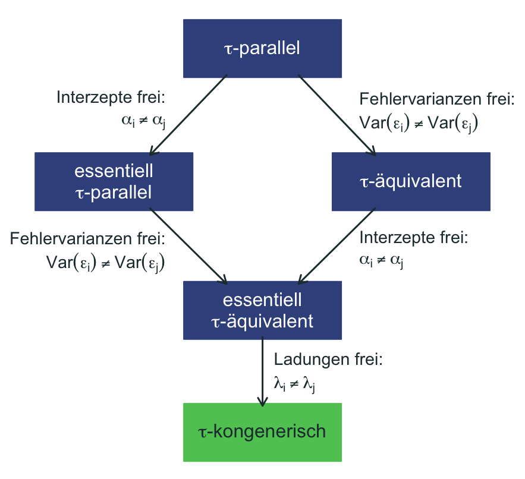

- Messmodelle machen unterschiedliche Annahmen über die Modellparameter (Interzept, Ladung, Fehlervarianz) der Items
- Daraus lassen sich Konsequenzen für die **Itemmittelwerte**, **Itemvarianzen** und **Itemkovarianzen** ableiten

## Abschließende Bemerkungen

Probleme der True-Score-Logik

- Die Grundgleichung bleibt empirisch ungeprüft (siehe: Gleichung 1)
- Annahme zu Messfehlern oft problematisch

**Borsbooms Konklusion**

> However, although various authors have warned against it, the platonic true score interpretation is like an alien in a B-movie: no matter how hard you beat it up, it keeps coming back. (Borsboom, 2005, S. 32)

# Übungsheft

## Übungen

Übungen zu diesem Thema: [Übungsheft, Kapitel 5](https://sbissantz.github.io/irtea/workbook/ctt-ex.html)

# Literaturverzeichnis

## Literatur

Borsboom, D. (2005). *Measuring the Mind: Conceptual Issues in Contemporary Psychometrics*. Cambridge University Press. https://doi.org/10.1017/CBO9780511490026

Coaley, K. (2014). *An Introduction to Psychological Assessment and Psychometrics* (2. Aufl.). SAGE Publications.

Moosbrugger, H., & Kelava, A. (Hrsg.). (2020). *Testtheorie und Fragebogenkonstruktion* (3. Aufl.). Springer Berlin Heidelberg. https://doi.org/10.1007/978-3-662-61532-4

# Anhang

## $\tau$-kongenerisches Messmodell

**Messwerte-Zerlegung**

$$\begin{split}
x_i &= \alpha_i + \lambda_i \cdot \eta + \varepsilon_i \\
x_j &= \alpha_j + \lambda_j \cdot \eta + \varepsilon_j \\
& i \ne j
\end{split}$$

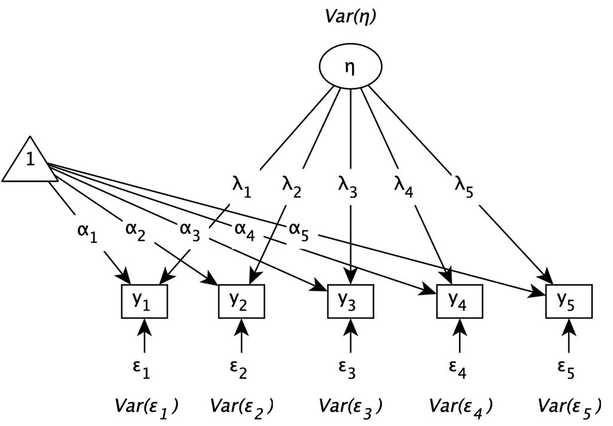

## Essentiell $\tau$-äquivalentes Messmodell

**Restriktion**

$$\lambda_i = \lambda_j$$

**Messwerte-Zerlegung**

$$\begin{split}
x_i &= \alpha_i + \lambda \cdot \eta + \varepsilon_i \\
x_j &= \alpha_j + \lambda \cdot \eta + \varepsilon_j \\
& i \ne j
\end{split}$$

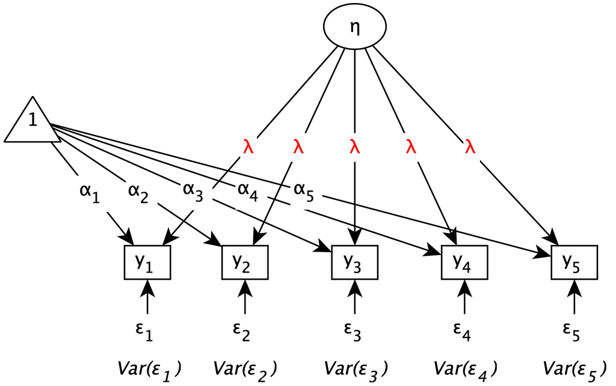

## $\tau$-äquivalentes Messmodell

**Restriktionen**

$$\begin{split}
\lambda_i = \lambda_j \\
\alpha_i = \alpha_j
\end{split}$$

**Messwerte-Zerlegung**

$$\begin{split}
x_i &= \alpha + \lambda \cdot \eta + \varepsilon_i \\
x_j &= \alpha + \lambda \cdot \eta + \varepsilon_j \\
& i \ne j
\end{split}$$

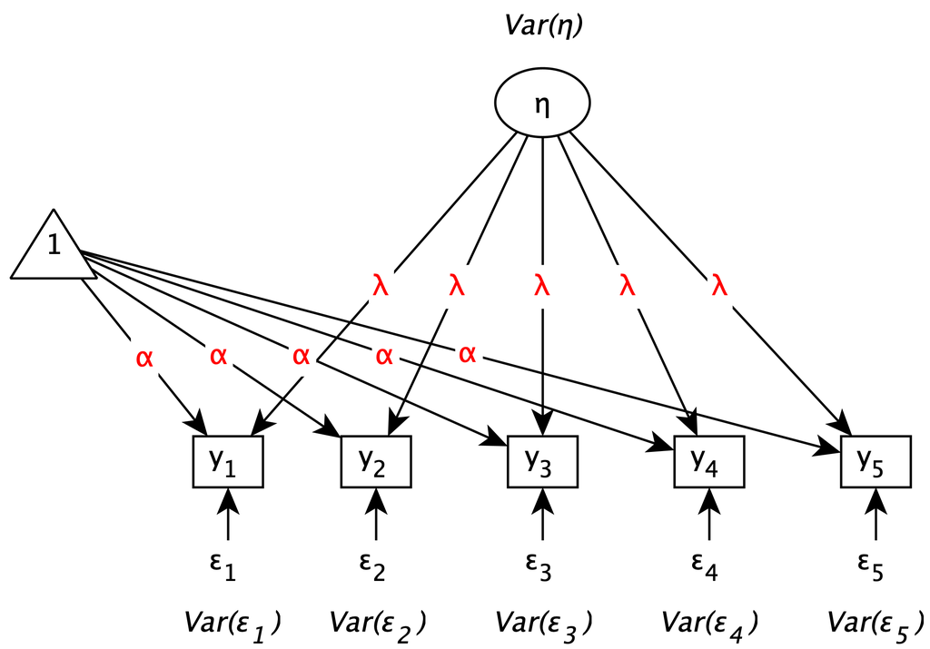

## Essentiell $\tau$-paralleles Messmodell

**Restriktionen**

$$\begin{split}
\lambda_i = \lambda_j \\
\text{Var}(\varepsilon_i) = \text{Var}(\varepsilon_j)
\end{split}$$

**Messwerte-Zerlegung**

$$\begin{split}
x_i &= \alpha_i + \lambda \cdot \eta + \varepsilon_i \\
x_j &= \alpha_j + \lambda \cdot \eta + \varepsilon_j \\
& i \ne j \\
& \text{Var}(\varepsilon_i) = \text{Var}(\varepsilon_j)
\end{split}$$

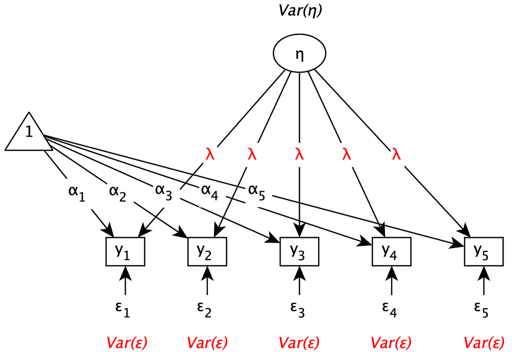

## $\tau$-paralleles Messmodell

**Restriktionen**

$$\begin{split}
\lambda_i = \lambda_j \\
\alpha_i = \alpha_j \\
\text{Var}(\varepsilon_i) = \text{Var}(\varepsilon_j)
\end{split}$$

**Messwerte-Zerlegung**

$$\begin{split}
x_i &= \alpha + \lambda \cdot \eta + \varepsilon_i \\
x_j &= \alpha + \lambda \cdot \eta + \varepsilon_j \\
& i \ne j \\
& \text{Var}(\varepsilon_i) = \text{Var}(\varepsilon_j)
\end{split}$$

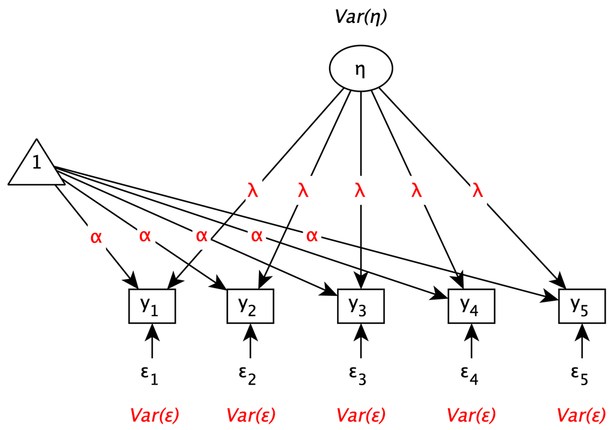